# Try the clValid package on the Exposome Challenge data set

Carles Criado Ninà

# 1 Introduction

clValid is an R package that provides a way to evaluate different clustering methods on the same data. It reports validation metrics that can be chosen between three classes: “internal”, “stability”, and “biological”.

First, I will evaluate the results over the metabolomics raw data. Then, I will do a PCA analysis, select the numbers of PCs that explain 80% of the variance, and repeat the analysis on the learned features. Finally, I will repeat the same two steps on the exposome data.

# 2 Load the data

First, we load the data previously saved on CSV files.

```r
directory <- "./ExposomeChallengeData/datasets"

# Exposome and metabolomics data (min-max normalized)
metabol_exprs <- read.csv(file.path(directory, "metabol_joint_exprs_minmax.csv"), row.names = 1)
exposome <- read.csv(file.path(directory, "exposome_minmax.csv"), row.names = 1)
```

# 3 Metabolomics data

## 3.1 Raw data

Try clValid on the raw data:

```r
CL_METHODS <- c("hierarchical", "kmeans", "diana", "som", "sota", "pam", "clara", "agnes")
N_CLUST <- 2:10
MAX_ITEMS <- nrow(metabol_exprs)

clval_metabol <- clValid(metabol_exprs,
                       nClust = N_CLUST,
                       clMethods = CL_METHODS,
                       maxitems = MAX_ITEMS,
                       validation = "internal",
                       metric = "euclidean",
                       method = "ward")

optimalScores(clval_metabol)
```

```
##                    Score       Method Clusters
## Connectivity 399.0067460 hierarchical        2
## Dunn           0.3129136        diana       10
## Silhouette     0.1031128       kmeans        2
```

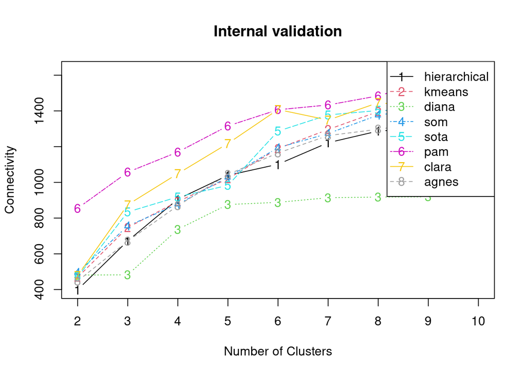

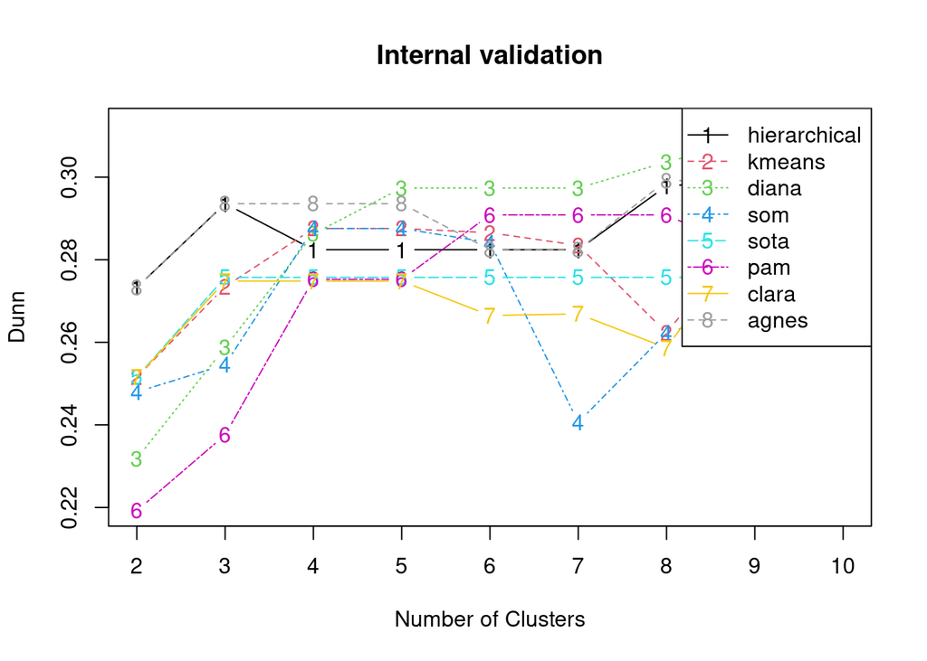

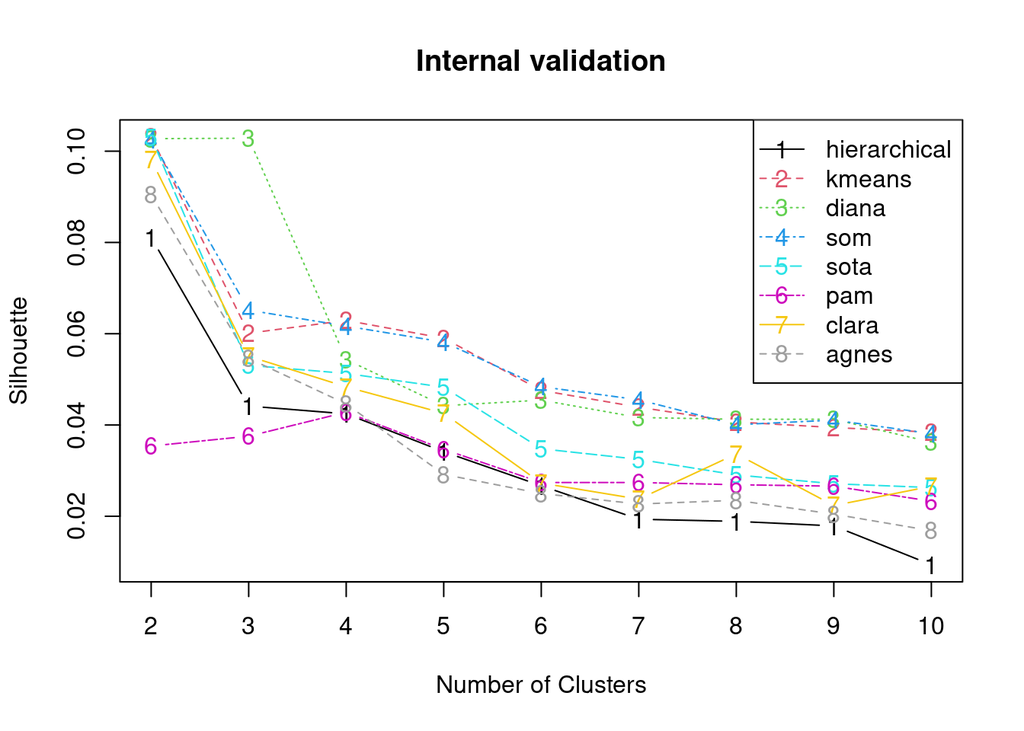

```r
plot(clval_metabol)
```

## 3.2 PCA

Try clValid on the learned features (PCA):

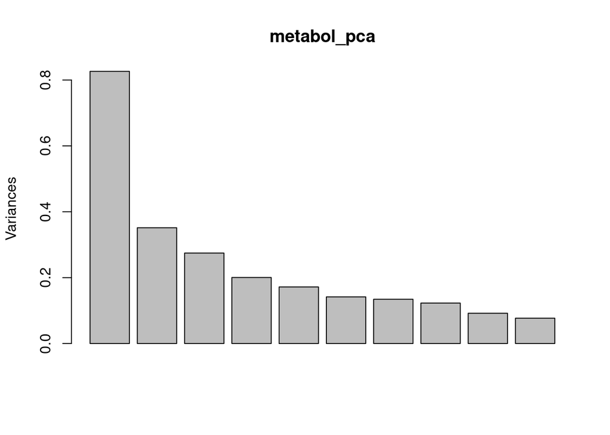

```r
EXPLAINED_VARIANCE = 0.8

metabol_pca <- prcomp(metabol_exprs)
plot(metabol_pca)
```

```r
num_pcs <- sum(summary(metabol_pca)$importance[3,] <= EXPLAINED_VARIANCE)
metabol_pca <- metabol_pca$x[,1:num_pcs]

clval_metabol_pca <- clValid(metabol_pca,
                       nClust = N_CLUST,
                       clMethods = CL_METHODS,
                       maxitems = MAX_ITEMS,
                       validation = "internal",
                       metric = "euclidean",
                       method = "ward")

optimalScores(clval_metabol_pca)
```

```
##                    Score       Method Clusters
## Connectivity 413.8670635 hierarchical        2
## Dunn           0.2684761 hierarchical       10
## Silhouette     0.1273295       kmeans        2
```

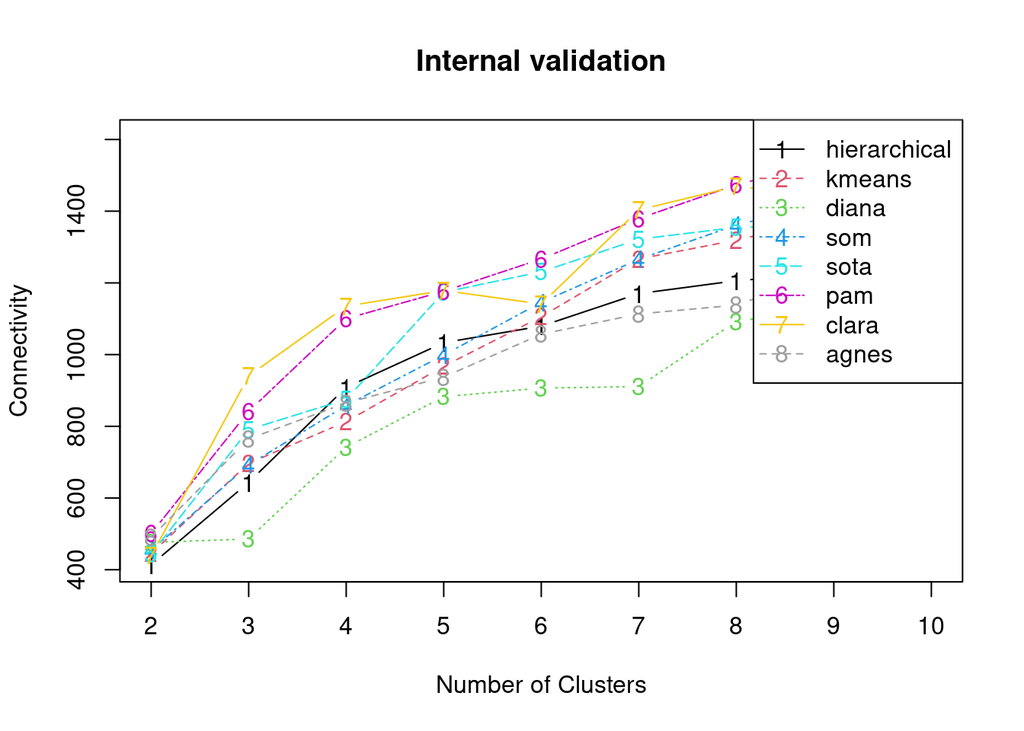

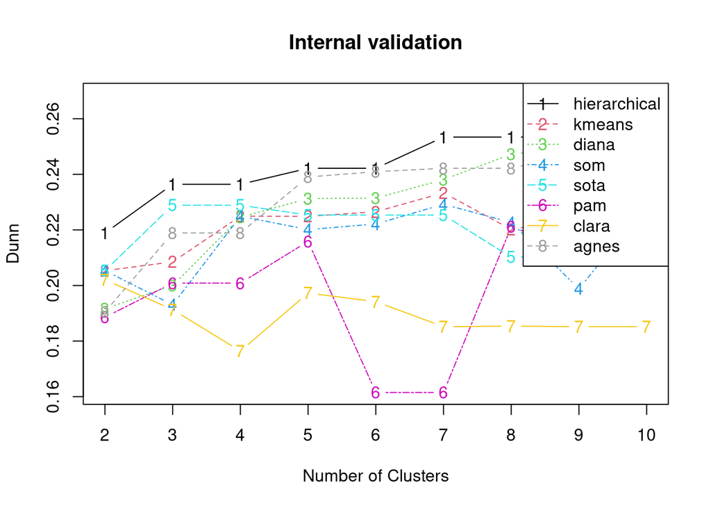

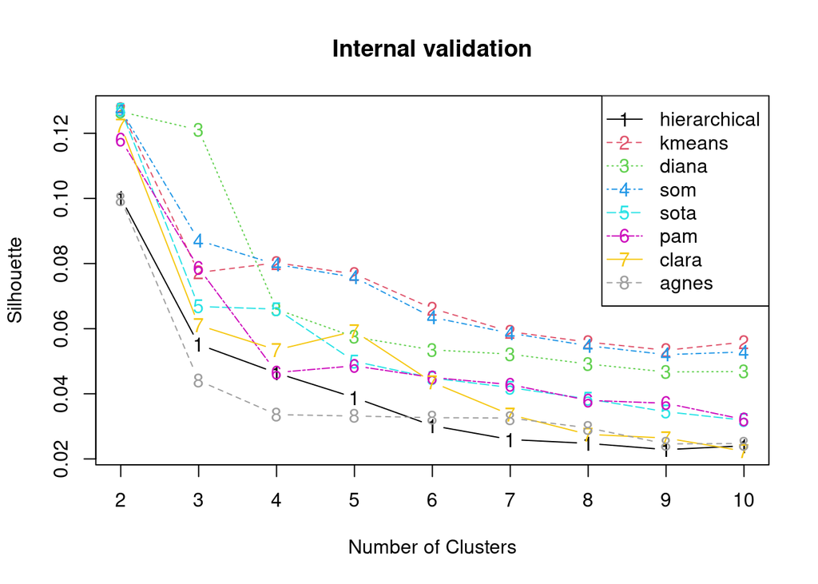

```r
plot(clval_metabol_pca)
```

The PCA transformation doesn’t seem to help, the results are very similar.

## 3.3 Try clValid on the exposome data

Try clValid on the raw data:

```r
clval_exposome <- clValid(exposome,
                       nClust = N_CLUST,
                       clMethods = CL_METHODS,
                       maxitems = MAX_ITEMS,
                       validation = "internal",
                       metric = "euclidean",
                       method = "ward")

optimalScores(clval_exposome)
```

```
##                  Score       Method Clusters
## Connectivity 5.3940476          som        2
## Dunn         0.5630790 hierarchical        3
## Silhouette   0.1214768          som        6
```

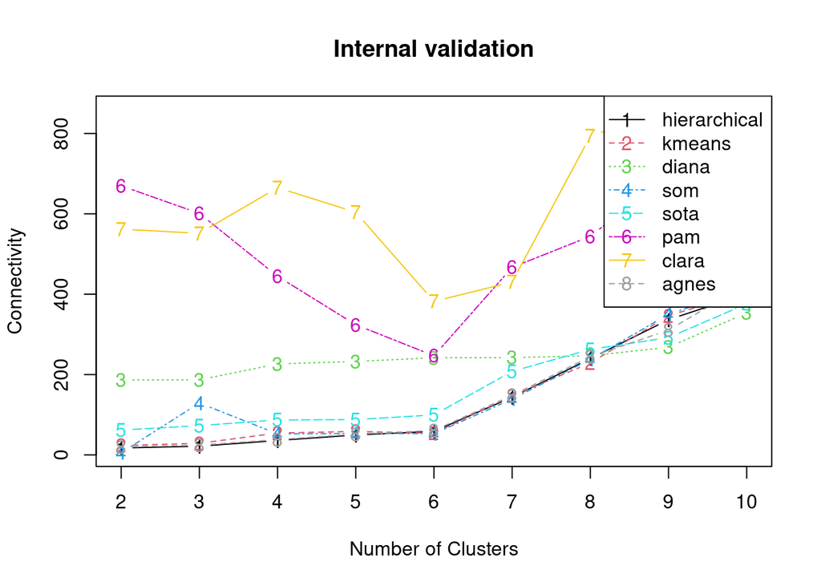

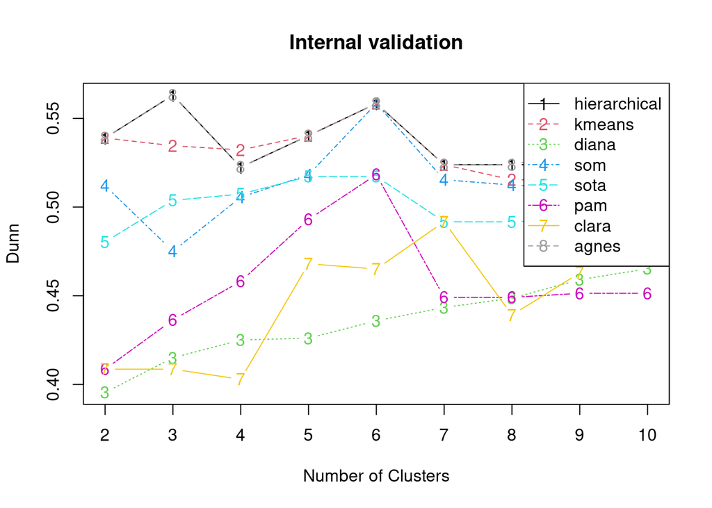

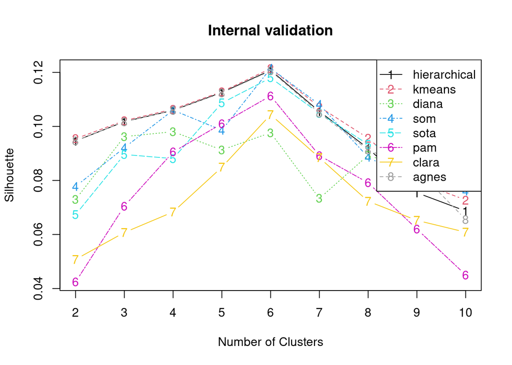

```r
plot(clval_exposome)
```

Here, I find that the majority of the methods converge in an **optimal number of 6 clusters**, which is confirms the results I found with both *classic* clustering methods and deep clustering methods (see Jupyter notebooks).

Try clValid on the learned features (PCA):

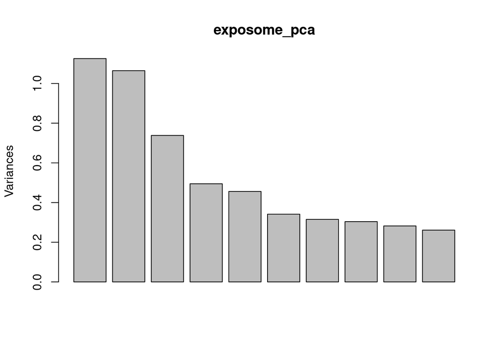

```r
exposome_pca <- prcomp(exposome)
plot(exposome_pca)
```

```r
num_pcs <- sum(summary(exposome_pca)$importance[3,] <= EXPLAINED_VARIANCE)
exposome_pca <- exposome_pca$x[,1:num_pcs]

clval_exposome_pca <- clValid(exposome_pca,
                       nClust = N_CLUST,
                       clMethods = CL_METHODS,
                       maxitems = MAX_ITEMS,
                       validation = "internal",
                       metric = "euclidean",
                       method = "ward")

optimalScores(clval_exposome_pca)
```

```
##                   Score       Method Clusters
## Connectivity 19.2313492 hierarchical        2
## Dunn          0.4812751       kmeans        6
## Silhouette    0.1586095          som        6
```

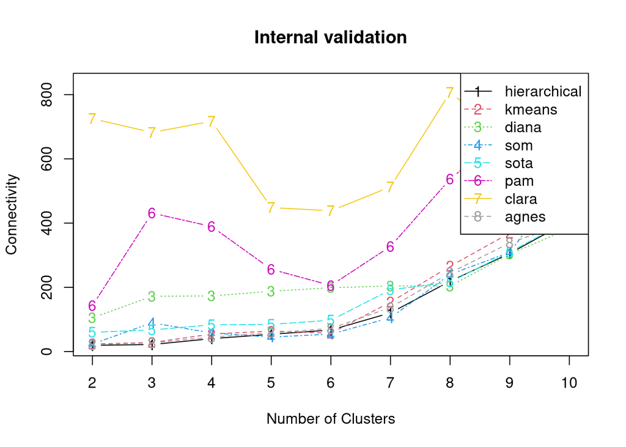

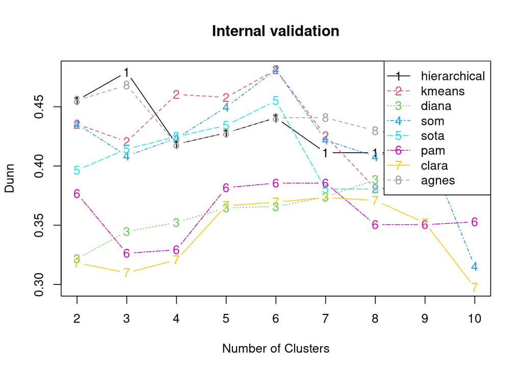

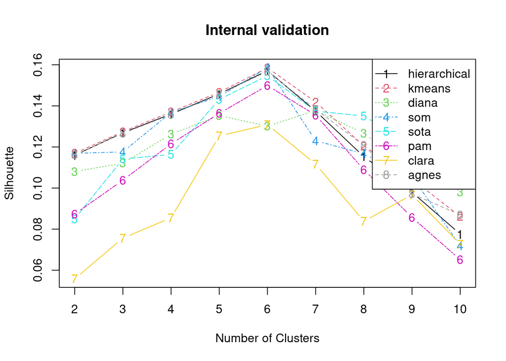

```r
plot(clval_exposome_pca)
```

The PCA converted data seem to reinforce the same result, finding again an optimal number 6 clusters, but with more pronounced differences.

# 4 Discussion

The results obtained with this exploration are in line with what I found on my earlier exploration trying different clustering methods, both *classic* methods and using deep learning (see Jupyter notebooks). The metabolomics data as provided does not seem to lend itself to good clustering quality.

On the other hand the exposome data shows a clear optimum number of 6 clusters with almost all the methods explored. On my earlier exploration I found that this clusters overlap with the classes of the variable *cohorts*, which suggests a that there is a strong batch effect on the data.